# Risk Factor Analysis

## Outcome Variable

**Outcome Variable:** wast_rec90d

## Predictor Variables

**Intervention Variable:** impfloor

**Adjustment Set:**

- arm
- sex
- W_mage
- meducyrs
- feducyrs
- hhwealth_quart
- hfoodsec
- W_mhtcm
- W_mwtkg
- W_mbmi
- W_nrooms
- W_nchldlt5
- W_parity
- impsan
- safeh20
- delta_W_mage
- delta_meducyrs
- delta_feducyrs
- delta_hhwealth_quart
- delta_hfoodsec
- delta_W_mhtcm
- delta_W_mwtkg
- delta_W_mbmi
- delta_W_nrooms
- delta_W_nchldlt5
- delta_W_parity
- delta_impsan
- delta_safeh20

## Stratifying Variables

The analysis was stratified on these variable(s):

- agecat
- studyid
- country

## Data Summary

| agecat | studyid | country | impfloor | wast_rec90d | n_cell | n |
| --- | --- | --- | --- | --- | --- | --- |
| 0-24 months | CMC-V-BCS-2002 | INDIA | 1 | 0 | 78 | 223 |
| 0-24 months | CMC-V-BCS-2002 | INDIA | 1 | 1 | 145 | 223 |
| 0-24 months | CMC-V-BCS-2002 | INDIA | 0 | 0 | 0 | 223 |
| 0-24 months | CMC-V-BCS-2002 | INDIA | 0 | 1 | 0 | 223 |
| 0-24 months | CONTENT | PERU | 1 | 0 | 1 | 7 |
| 0-24 months | CONTENT | PERU | 1 | 1 | 6 | 7 |
| 0-24 months | CONTENT | PERU | 0 | 0 | 0 | 7 |
| 0-24 months | CONTENT | PERU | 0 | 1 | 0 | 7 |
| 0-24 months | GMS-Nepal | NEPAL | 1 | 0 | 47 | 504 |
| 0-24 months | GMS-Nepal | NEPAL | 1 | 1 | 36 | 504 |
| 0-24 months | GMS-Nepal | NEPAL | 0 | 0 | 185 | 504 |
| 0-24 months | GMS-Nepal | NEPAL | 0 | 1 | 236 | 504 |
| 0-24 months | IRC | INDIA | 1 | 0 | 128 | 308 |
| 0-24 months | IRC | INDIA | 1 | 1 | 180 | 308 |
| 0-24 months | IRC | INDIA | 0 | 0 | 0 | 308 |
| 0-24 months | IRC | INDIA | 0 | 1 | 0 | 308 |
| 0-24 months | JiVitA-3 | BANGLADESH | 1 | 0 | 294 | 7545 |
| 0-24 months | JiVitA-3 | BANGLADESH | 1 | 1 | 259 | 7545 |
| 0-24 months | JiVitA-3 | BANGLADESH | 0 | 0 | 4062 | 7545 |
| 0-24 months | JiVitA-3 | BANGLADESH | 0 | 1 | 2930 | 7545 |
| 0-24 months | JiVitA-4 | BANGLADESH | 1 | 0 | 135 | 2062 |
| 0-24 months | JiVitA-4 | BANGLADESH | 1 | 1 | 58 | 2062 |
| 0-24 months | JiVitA-4 | BANGLADESH | 0 | 0 | 1395 | 2062 |
| 0-24 months | JiVitA-4 | BANGLADESH | 0 | 1 | 474 | 2062 |
| 0-24 months | MAL-ED | BANGLADESH | 1 | 0 | 37 | 121 |
| 0-24 months | MAL-ED | BANGLADESH | 1 | 1 | 73 | 121 |
| 0-24 months | MAL-ED | BANGLADESH | 0 | 0 | 6 | 121 |
| 0-24 months | MAL-ED | BANGLADESH | 0 | 1 | 5 | 121 |
| 0-24 months | MAL-ED | BRAZIL | 1 | 0 | 6 | 24 |
| 0-24 months | MAL-ED | BRAZIL | 1 | 1 | 18 | 24 |

[output cut: 162 more lines]

The following strata were considered:

- agecat: 0-24 months, studyid: CMC-V-BCS-2002, country: INDIA
- agecat: 0-24 months, studyid: CONTENT, country: PERU
- agecat: 0-24 months, studyid: GMS-Nepal, country: NEPAL
- agecat: 0-24 months, studyid: IRC, country: INDIA
- agecat: 0-24 months, studyid: JiVitA-3, country: BANGLADESH
- agecat: 0-24 months, studyid: JiVitA-4, country: BANGLADESH
- agecat: 0-24 months, studyid: MAL-ED, country: BANGLADESH
- agecat: 0-24 months, studyid: MAL-ED, country: BRAZIL
- agecat: 0-24 months, studyid: MAL-ED, country: INDIA
- agecat: 0-24 months, studyid: MAL-ED, country: NEPAL
- agecat: 0-24 months, studyid: MAL-ED, country: PERU
- agecat: 0-24 months, studyid: MAL-ED, country: SOUTH AFRICA
- agecat: 0-24 months, studyid: MAL-ED, country: TANZANIA, UNITED REPUBLIC OF
- agecat: 0-24 months, studyid: NIH-Birth, country: BANGLADESH
- agecat: 0-24 months, studyid: NIH-Crypto, country: BANGLADESH
- agecat: 0-24 months, studyid: PROVIDE, country: BANGLADESH
- agecat: 0-6 months, studyid: CMC-V-BCS-2002, country: INDIA
- agecat: 0-6 months, studyid: CONTENT, country: PERU
- agecat: 0-6 months, studyid: GMS-Nepal, country: NEPAL
- agecat: 0-6 months, studyid: IRC, country: INDIA
- agecat: 0-6 months, studyid: JiVitA-3, country: BANGLADESH
- agecat: 0-6 months, studyid: JiVitA-4, country: BANGLADESH
- agecat: 0-6 months, studyid: MAL-ED, country: BANGLADESH
- agecat: 0-6 months, studyid: MAL-ED, country: BRAZIL
- agecat: 0-6 months, studyid: MAL-ED, country: INDIA
- agecat: 0-6 months, studyid: MAL-ED, country: NEPAL
- agecat: 0-6 months, studyid: MAL-ED, country: PERU
- agecat: 0-6 months, studyid: MAL-ED, country: SOUTH AFRICA
- agecat: 0-6 months, studyid: MAL-ED, country: TANZANIA, UNITED REPUBLIC OF
- agecat: 0-6 months, studyid: NIH-Birth, country: BANGLADESH
- agecat: 0-6 months, studyid: NIH-Crypto, country: BANGLADESH
- agecat: 0-6 months, studyid: PROVIDE, country: BANGLADESH
- agecat: 6-24 months, studyid: CMC-V-BCS-2002, country: INDIA
- agecat: 6-24 months, studyid: CONTENT, country: PERU
- agecat: 6-24 months, studyid: GMS-Nepal, country: NEPAL
- agecat: 6-24 months, studyid: IRC, country: INDIA
- agecat: 6-24 months, studyid: JiVitA-3, country: BANGLADESH
- agecat: 6-24 months, studyid: JiVitA-4, country: BANGLADESH
- agecat: 6-24 months, studyid: MAL-ED, country: BANGLADESH
- agecat: 6-24 months, studyid: MAL-ED, country: BRAZIL
- agecat: 6-24 months, studyid: MAL-ED, country: INDIA
- agecat: 6-24 months, studyid: MAL-ED, country: NEPAL
- agecat: 6-24 months, studyid: MAL-ED, country: PERU
- agecat: 6-24 months, studyid: MAL-ED, country: SOUTH AFRICA
- agecat: 6-24 months, studyid: MAL-ED, country: TANZANIA, UNITED REPUBLIC OF
- agecat: 6-24 months, studyid: NIH-Birth, country: BANGLADESH
- agecat: 6-24 months, studyid: NIH-Crypto, country: BANGLADESH
- agecat: 6-24 months, studyid: PROVIDE, country: BANGLADESH

### Dropped Strata

Some strata were dropped due to rare outcomes:

- agecat: 0-24 months, studyid: CMC-V-BCS-2002, country: INDIA
- agecat: 0-24 months, studyid: CONTENT, country: PERU
- agecat: 0-24 months, studyid: IRC, country: INDIA
- agecat: 0-24 months, studyid: MAL-ED, country: BRAZIL
- agecat: 0-24 months, studyid: MAL-ED, country: PERU
- agecat: 0-24 months, studyid: MAL-ED, country: SOUTH AFRICA
- agecat: 0-24 months, studyid: MAL-ED, country: TANZANIA, UNITED REPUBLIC OF
- agecat: 0-6 months, studyid: CMC-V-BCS-2002, country: INDIA
- agecat: 0-6 months, studyid: CONTENT, country: PERU
- agecat: 0-6 months, studyid: IRC, country: INDIA
- agecat: 0-6 months, studyid: MAL-ED, country: BANGLADESH
- agecat: 0-6 months, studyid: MAL-ED, country: BRAZIL
- agecat: 0-6 months, studyid: MAL-ED, country: INDIA
- agecat: 0-6 months, studyid: MAL-ED, country: NEPAL
- agecat: 0-6 months, studyid: MAL-ED, country: PERU
- agecat: 0-6 months, studyid: MAL-ED, country: SOUTH AFRICA
- agecat: 0-6 months, studyid: MAL-ED, country: TANZANIA, UNITED REPUBLIC OF
- agecat: 0-6 months, studyid: NIH-Crypto, country: BANGLADESH
- agecat: 6-24 months, studyid: CMC-V-BCS-2002, country: INDIA
- agecat: 6-24 months, studyid: CONTENT, country: PERU
- agecat: 6-24 months, studyid: IRC, country: INDIA
- agecat: 6-24 months, studyid: JiVitA-3, country: BANGLADESH
- agecat: 6-24 months, studyid: MAL-ED, country: BANGLADESH
- agecat: 6-24 months, studyid: MAL-ED, country: BRAZIL
- agecat: 6-24 months, studyid: MAL-ED, country: NEPAL
- agecat: 6-24 months, studyid: MAL-ED, country: PERU
- agecat: 6-24 months, studyid: MAL-ED, country: SOUTH AFRICA
- agecat: 6-24 months, studyid: MAL-ED, country: TANZANIA, UNITED REPUBLIC OF
- agecat: 6-24 months, studyid: NIH-Crypto, country: BANGLADESH
- agecat: 6-24 months, studyid: PROVIDE, country: BANGLADESH

## Methods Detail

We’re interested in the causal parameters $E[Y_a]$ for all values of $a \in \mathcal{A}$. These parameters represent the mean outcome if, possibly contrary to fact, we intervened to set all units to have $A=a$. Under the randomization and positivity assumptions, these are identified by the statistical parameters $\psi_a=E_W[E_{Y|A,W}(Y|A=a,W)]$. In addition, we’re interested in the mean of $Y$, $E[Y]$ under no intervention (the observed mean). We will estimate these parameters by using SuperLearner to fit the relevant likelihood factors – $E_{Y|A,W}(Y|A=a,W)$ and $p(A=a|W)$, and then updating our likelihood fit using a joint TMLE.

For unadjusted analyses ($W=\{\}$), initial likelihoods were estimated using Lrnr_glm to estimate the simple $E(Y|A)$ and Lrnr_mean to estimate $p(A)$. For adjusted analyses, a small library containing Lrnr_glmnet, Lrnr_xgboost, and Lrnr_mean was used.

Having estimated these parameters, we will then use the delta method to estimate relative risks and attributable risks relative to a prespecified baseline level of $A$.

# Results Detail

## Results Plots

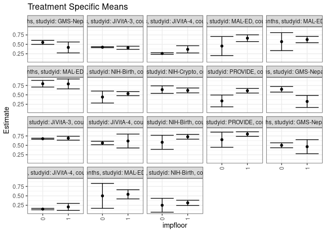

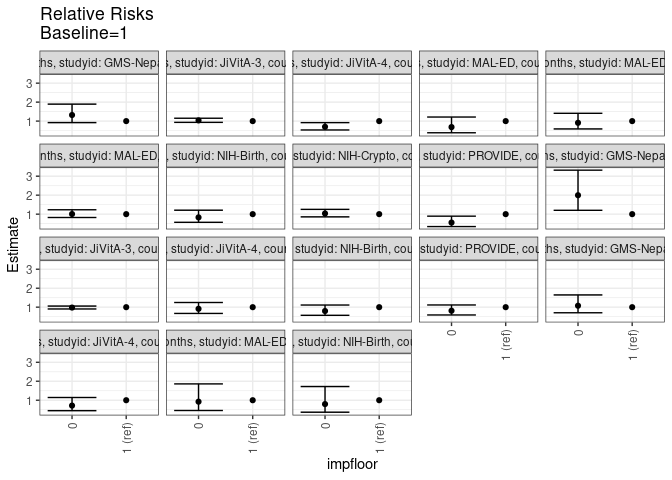

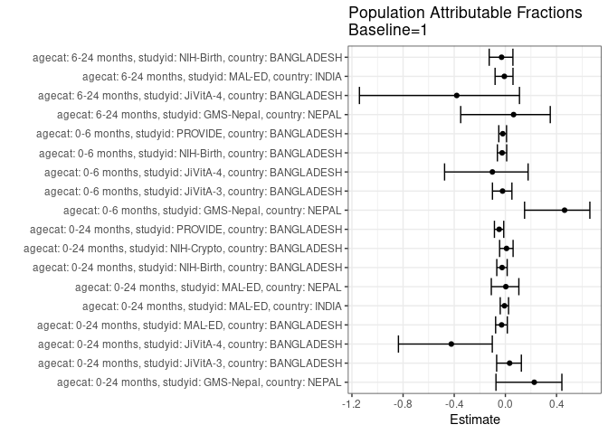

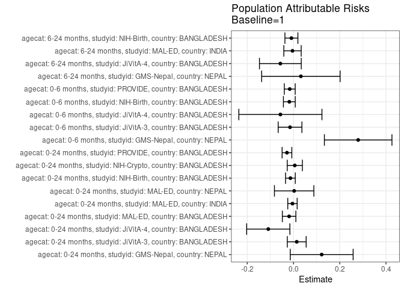

## Results Table

### Parameter: TSM

| agecat | studyid | country | intervention_level | baseline_level | estimate | ci_lower | ci_upper |
| --- | --- | --- | --- | --- | --- | --- | --- |
| 0-24 months | GMS-Nepal | NEPAL | 1 | NA | 0.4177715 | 0.2727200 | 0.5628230 |
| 0-24 months | GMS-Nepal | NEPAL | 0 | NA | 0.5519804 | 0.4986596 | 0.6053012 |
| 0-24 months | JiVitA-3 | BANGLADESH | 1 | NA | 0.4086320 | 0.3673795 | 0.4498846 |
| 0-24 months | JiVitA-3 | BANGLADESH | 0 | NA | 0.4237782 | 0.4116981 | 0.4358583 |
| 0-24 months | JiVitA-4 | BANGLADESH | 1 | NA | 0.3670709 | 0.2713873 | 0.4627545 |
| 0-24 months | JiVitA-4 | BANGLADESH | 0 | NA | 0.2569546 | 0.2357243 | 0.2781849 |
| 0-24 months | MAL-ED | BANGLADESH | 1 | NA | 0.6636364 | 0.5737409 | 0.7535318 |
| 0-24 months | MAL-ED | BANGLADESH | 0 | NA | 0.4545455 | 0.2011212 | 0.7079697 |
| 0-24 months | MAL-ED | INDIA | 1 | NA | 0.6273292 | 0.5434386 | 0.7112198 |
| 0-24 months | MAL-ED | INDIA | 0 | NA | 0.5714286 | 0.3326866 | 0.8101705 |
| 0-24 months | MAL-ED | NEPAL | 1 | NA | 0.7906977 | 0.6589695 | 0.9224259 |
| 0-24 months | MAL-ED | NEPAL | 0 | NA | 0.7959184 | 0.7066152 | 0.8852215 |
| 0-24 months | NIH-Birth | BANGLADESH | 1 | NA | 0.5324851 | 0.4781285 | 0.5868417 |
| 0-24 months | NIH-Birth | BANGLADESH | 0 | NA | 0.4416869 | 0.2821186 | 0.6012552 |
| 0-24 months | NIH-Crypto | BANGLADESH | 1 | NA | 0.6169582 | 0.5522983 | 0.6816182 |
| 0-24 months | NIH-Crypto | BANGLADESH | 0 | NA | 0.6389501 | 0.5386187 | 0.7392814 |
| 0-24 months | PROVIDE | BANGLADESH | 1 | NA | 0.6094233 | 0.5488665 | 0.6699802 |
| 0-24 months | PROVIDE | BANGLADESH | 0 | NA | 0.3386581 | 0.1813048 | 0.4960114 |
| 0-6 months | GMS-Nepal | NEPAL | 1 | NA | 0.3243255 | 0.1641597 | 0.4844914 |
| 0-6 months | GMS-Nepal | NEPAL | 0 | NA | 0.6478696 | 0.5740597 | 0.7216796 |
| 0-6 months | JiVitA-3 | BANGLADESH | 1 | NA | 0.6907491 | 0.6389232 | 0.7425749 |
| 0-6 months | JiVitA-3 | BANGLADESH | 0 | NA | 0.6766275 | 0.6623315 | 0.6909235 |
| 0-6 months | JiVitA-4 | BANGLADESH | 1 | NA | 0.6150630 | 0.4309623 | 0.7991637 |
| 0-6 months | JiVitA-4 | BANGLADESH | 0 | NA | 0.5626185 | 0.5163350 | 0.6089019 |
| 0-6 months | NIH-Birth | BANGLADESH | 1 | NA | 0.7284433 | 0.6655004 | 0.7913862 |
| 0-6 months | NIH-Birth | BANGLADESH | 0 | NA | 0.5813895 | 0.3945191 | 0.7682599 |
| 0-6 months | PROVIDE | BANGLADESH | 1 | NA | 0.8000000 | 0.7395838 | 0.8604162 |
| 0-6 months | PROVIDE | BANGLADESH | 0 | NA | 0.6500000 | 0.4484303 | 0.8515697 |
| 6-24 months | GMS-Nepal | NEPAL | 1 | NA | 0.4647930 | 0.2779958 | 0.6515903 |
| 6-24 months | GMS-Nepal | NEPAL | 0 | NA | 0.5010953 | 0.4357765 | 0.5664141 |
| 6-24 months | JiVitA-4 | BANGLADESH | 1 | NA | 0.2060440 | 0.1135983 | 0.2984896 |
| 6-24 months | JiVitA-4 | BANGLADESH | 0 | NA | 0.1476507 | 0.1288369 | 0.1664646 |
| 6-24 months | MAL-ED | INDIA | 1 | NA | 0.5411765 | 0.4195451 | 0.6628078 |
| 6-24 months | MAL-ED | INDIA | 0 | NA | 0.5000000 | 0.1687592 | 0.8312408 |
| 6-24 months | NIH-Birth | BANGLADESH | 1 | NA | 0.3136095 | 0.2434845 | 0.3837345 |
| 6-24 months | NIH-Birth | BANGLADESH | 0 | NA | 0.2500000 | 0.0656374 | 0.4343626 |

### Parameter: E(Y)

| agecat | studyid | country | intervention_level | baseline_level | estimate | ci_lower | ci_upper |
| --- | --- | --- | --- | --- | --- | --- | --- |
| 0-24 months | GMS-Nepal | NEPAL | NA | NA | 0.5396825 | 0.4917879 | 0.5875772 |
| 0-24 months | JiVitA-3 | BANGLADESH | NA | NA | 0.4226640 | 0.4115226 | 0.4338055 |
| 0-24 months | JiVitA-4 | BANGLADESH | NA | NA | 0.2580019 | 0.2386523 | 0.2773515 |
| 0-24 months | MAL-ED | BANGLADESH | NA | NA | 0.6446281 | 0.5577732 | 0.7314830 |
| 0-24 months | MAL-ED | INDIA | NA | NA | 0.6228571 | 0.5433246 | 0.7023896 |
| 0-24 months | MAL-ED | NEPAL | NA | NA | 0.7934783 | 0.7160127 | 0.8709439 |
| 0-24 months | NIH-Birth | BANGLADESH | NA | NA | 0.5191388 | 0.4683286 | 0.5699489 |
| 0-24 months | NIH-Crypto | BANGLADESH | NA | NA | 0.6225806 | 0.5684562 | 0.6767051 |
| 0-24 months | PROVIDE | BANGLADESH | NA | NA | 0.5811688 | 0.5245443 | 0.6377934 |
| 0-6 months | GMS-Nepal | NEPAL | NA | NA | 0.6039604 | 0.5356875 | 0.6722333 |
| 0-6 months | JiVitA-3 | BANGLADESH | NA | NA | 0.6757788 | 0.6624235 | 0.6891341 |
| 0-6 months | JiVitA-4 | BANGLADESH | NA | NA | 0.5583942 | 0.5167799 | 0.6000084 |
| 0-6 months | NIH-Birth | BANGLADESH | NA | NA | 0.7104072 | 0.6505603 | 0.7702542 |
| 0-6 months | PROVIDE | BANGLADESH | NA | NA | 0.7837838 | 0.7252863 | 0.8422812 |
| 6-24 months | GMS-Nepal | NEPAL | NA | NA | 0.4966887 | 0.4351829 | 0.5581945 |
| 6-24 months | JiVitA-4 | BANGLADESH | NA | NA | 0.1492734 | 0.1316631 | 0.1668838 |
| 6-24 months | MAL-ED | INDIA | NA | NA | 0.5368421 | 0.4223932 | 0.6512910 |
| 6-24 months | NIH-Birth | BANGLADESH | NA | NA | 0.3045685 | 0.2390070 | 0.3701301 |

### Parameter: RR

| agecat | studyid | country | intervention_level | baseline_level | estimate | ci_lower | ci_upper |
| --- | --- | --- | --- | --- | --- | --- | --- |
| 0-24 months | GMS-Nepal | NEPAL | 1 | 1 | 1.0000000 | 1.0000000 | 1.0000000 |
| 0-24 months | GMS-Nepal | NEPAL | 0 | 1 | 1.3212495 | 0.9214369 | 1.8945414 |
| 0-24 months | JiVitA-3 | BANGLADESH | 1 | 1 | 1.0000000 | 1.0000000 | 1.0000000 |
| 0-24 months | JiVitA-3 | BANGLADESH | 0 | 1 | 1.0370656 | 0.9340577 | 1.1514333 |
| 0-24 months | JiVitA-4 | BANGLADESH | 1 | 1 | 1.0000000 | 1.0000000 | 1.0000000 |
| 0-24 months | JiVitA-4 | BANGLADESH | 0 | 1 | 0.7000135 | 0.5324048 | 0.9203877 |
| 0-24 months | MAL-ED | BANGLADESH | 1 | 1 | 1.0000000 | 1.0000000 | 1.0000000 |
| 0-24 months | MAL-ED | BANGLADESH | 0 | 1 | 0.6849315 | 0.3861446 | 1.2149107 |
| 0-24 months | MAL-ED | INDIA | 1 | 1 | 1.0000000 | 1.0000000 | 1.0000000 |
| 0-24 months | MAL-ED | INDIA | 0 | 1 | 0.9108911 | 0.5874231 | 1.4124786 |
| 0-24 months | MAL-ED | NEPAL | 1 | 1 | 1.0000000 | 1.0000000 | 1.0000000 |
| 0-24 months | MAL-ED | NEPAL | 0 | 1 | 1.0066026 | 0.8227214 | 1.2315819 |
| 0-24 months | NIH-Birth | BANGLADESH | 1 | 1 | 1.0000000 | 1.0000000 | 1.0000000 |
| 0-24 months | NIH-Birth | BANGLADESH | 0 | 1 | 0.8294822 | 0.5696446 | 1.2078421 |
| 0-24 months | NIH-Crypto | BANGLADESH | 1 | 1 | 1.0000000 | 1.0000000 | 1.0000000 |
| 0-24 months | NIH-Crypto | BANGLADESH | 0 | 1 | 1.0356456 | 0.8568893 | 1.2516924 |
| 0-24 months | PROVIDE | BANGLADESH | 1 | 1 | 1.0000000 | 1.0000000 | 1.0000000 |
| 0-24 months | PROVIDE | BANGLADESH | 0 | 1 | 0.5557025 | 0.3453498 | 0.8941813 |
| 0-6 months | GMS-Nepal | NEPAL | 1 | 1 | 1.0000000 | 1.0000000 | 1.0000000 |
| 0-6 months | GMS-Nepal | NEPAL | 0 | 1 | 1.9975904 | 1.2025604 | 3.3182264 |
| 0-6 months | JiVitA-3 | BANGLADESH | 1 | 1 | 1.0000000 | 1.0000000 | 1.0000000 |
| 0-6 months | JiVitA-3 | BANGLADESH | 0 | 1 | 0.9795561 | 0.9061271 | 1.0589356 |
| 0-6 months | JiVitA-4 | BANGLADESH | 1 | 1 | 1.0000000 | 1.0000000 | 1.0000000 |
| 0-6 months | JiVitA-4 | BANGLADESH | 0 | 1 | 0.9147330 | 0.6705348 | 1.2478643 |
| 0-6 months | NIH-Birth | BANGLADESH | 1 | 1 | 1.0000000 | 1.0000000 | 1.0000000 |
| 0-6 months | NIH-Birth | BANGLADESH | 0 | 1 | 0.7981259 | 0.5722890 | 1.1130828 |
| 0-6 months | PROVIDE | BANGLADESH | 1 | 1 | 1.0000000 | 1.0000000 | 1.0000000 |
| 0-6 months | PROVIDE | BANGLADESH | 0 | 1 | 0.8125000 | 0.5904824 | 1.1179948 |
| 6-24 months | GMS-Nepal | NEPAL | 1 | 1 | 1.0000000 | 1.0000000 | 1.0000000 |
| 6-24 months | GMS-Nepal | NEPAL | 0 | 1 | 1.0781041 | 0.7062354 | 1.6457805 |
| 6-24 months | JiVitA-4 | BANGLADESH | 1 | 1 | 1.0000000 | 1.0000000 | 1.0000000 |
| 6-24 months | JiVitA-4 | BANGLADESH | 0 | 1 | 0.7165982 | 0.4494477 | 1.1425423 |
| 6-24 months | MAL-ED | INDIA | 1 | 1 | 1.0000000 | 1.0000000 | 1.0000000 |
| 6-24 months | MAL-ED | INDIA | 0 | 1 | 0.9239130 | 0.4590405 | 1.8595643 |
| 6-24 months | NIH-Birth | BANGLADESH | 1 | 1 | 1.0000000 | 1.0000000 | 1.0000000 |
| 6-24 months | NIH-Birth | BANGLADESH | 0 | 1 | 0.7971698 | 0.3690609 | 1.7218829 |

### Parameter: PAR

| agecat | studyid | country | intervention_level | baseline_level | estimate | ci_lower | ci_upper |
| --- | --- | --- | --- | --- | --- | --- | --- |
| 0-24 months | GMS-Nepal | NEPAL | 1 | NA | 0.1219110 | -0.0140813 | 0.2579034 |
| 0-24 months | JiVitA-3 | BANGLADESH | 1 | NA | 0.0140320 | -0.0267591 | 0.0548231 |
| 0-24 months | JiVitA-4 | BANGLADESH | 1 | NA | -0.1090689 | -0.2024956 | -0.0156423 |
| 0-24 months | MAL-ED | BANGLADESH | 1 | NA | -0.0190083 | -0.0482288 | 0.0102123 |
| 0-24 months | MAL-ED | INDIA | 1 | NA | -0.0044720 | -0.0248142 | 0.0158701 |
| 0-24 months | MAL-ED | NEPAL | 1 | NA | 0.0027806 | -0.0824301 | 0.0879912 |
| 0-24 months | NIH-Birth | BANGLADESH | 1 | NA | -0.0133463 | -0.0343681 | 0.0076754 |
| 0-24 months | NIH-Crypto | BANGLADESH | 1 | NA | 0.0056224 | -0.0271377 | 0.0383825 |
| 0-24 months | PROVIDE | BANGLADESH | 1 | NA | -0.0282545 | -0.0492393 | -0.0072696 |
| 0-6 months | GMS-Nepal | NEPAL | 1 | NA | 0.2796348 | 0.1335459 | 0.4257238 |
| 0-6 months | JiVitA-3 | BANGLADESH | 1 | NA | -0.0149703 | -0.0662902 | 0.0363496 |
| 0-6 months | JiVitA-4 | BANGLADESH | 1 | NA | -0.0566689 | -0.2363731 | 0.1230354 |
| 0-6 months | NIH-Birth | BANGLADESH | 1 | NA | -0.0180361 | -0.0436305 | 0.0075584 |
| 0-6 months | PROVIDE | BANGLADESH | 1 | NA | -0.0162162 | -0.0398277 | 0.0073953 |
| 6-24 months | GMS-Nepal | NEPAL | 1 | NA | 0.0318957 | -0.1377188 | 0.2015102 |
| 6-24 months | JiVitA-4 | BANGLADESH | 1 | NA | -0.0567705 | -0.1471419 | 0.0336008 |
| 6-24 months | MAL-ED | INDIA | 1 | NA | -0.0043344 | -0.0419154 | 0.0332466 |
| 6-24 months | NIH-Birth | BANGLADESH | 1 | NA | -0.0090409 | -0.0370914 | 0.0190095 |

### Parameter: PAF

| agecat | studyid | country | intervention_level | baseline_level | estimate | ci_lower | ci_upper |
| --- | --- | --- | --- | --- | --- | --- | --- |
| 0-24 months | GMS-Nepal | NEPAL | 1 | NA | 0.2258940 | -0.0735810 | 0.4418306 |
| 0-24 months | JiVitA-3 | BANGLADESH | 1 | NA | 0.0331990 | -0.0682045 | 0.1249763 |
| 0-24 months | JiVitA-4 | BANGLADESH | 1 | NA | -0.4227447 | -0.8363118 | -0.1023196 |
| 0-24 months | MAL-ED | BANGLADESH | 1 | NA | -0.0294872 | -0.0762681 | 0.0152603 |
| 0-24 months | MAL-ED | INDIA | 1 | NA | -0.0071799 | -0.0403006 | 0.0248863 |
| 0-24 months | MAL-ED | NEPAL | 1 | NA | 0.0035043 | -0.1100031 | 0.1054046 |
| 0-24 months | NIH-Birth | BANGLADESH | 1 | NA | -0.0257086 | -0.0671776 | 0.0141489 |
| 0-24 months | NIH-Crypto | BANGLADESH | 1 | NA | 0.0090308 | -0.0450590 | 0.0603210 |
| 0-24 months | PROVIDE | BANGLADESH | 1 | NA | -0.0486167 | -0.0856320 | -0.0128634 |
| 0-6 months | GMS-Nepal | NEPAL | 1 | NA | 0.4630020 | 0.1500454 | 0.6607267 |
| 0-6 months | JiVitA-3 | BANGLADESH | 1 | NA | -0.0221527 | -0.1010316 | 0.0510752 |
| 0-6 months | JiVitA-4 | BANGLADESH | 1 | NA | -0.1014854 | -0.4754650 | 0.1777032 |
| 0-6 months | NIH-Birth | BANGLADESH | 1 | NA | -0.0253883 | -0.0623203 | 0.0102596 |
| 0-6 months | PROVIDE | BANGLADESH | 1 | NA | -0.0206897 | -0.0514932 | 0.0092115 |
| 6-24 months | GMS-Nepal | NEPAL | 1 | NA | 0.0642167 | -0.3493249 | 0.3510159 |
| 6-24 months | JiVitA-4 | BANGLADESH | 1 | NA | -0.3803122 | -1.1412946 | 0.1102291 |
| 6-24 months | MAL-ED | INDIA | 1 | NA | -0.0080738 | -0.0805275 | 0.0595215 |
| 6-24 months | NIH-Birth | BANGLADESH | 1 | NA | -0.0296844 | -0.1265874 | 0.0588835 |